# Reverse Geocoding: Acquiring Address from Location Coordinates

Author

Arga Adyatama

Published

March 23, 2024

# Introduction

**Geocoding** is the process of converting addresses into geographic coordinates (latitude and longitude). You see their familiar form whenever you search for your local restaurant or place to visit. There is also something called **Reverse Geocoding** where you want to convert latitude and longitude into readable addresses. Both are equally important, especially for industries related to moving goods or people, e.g. food delivery service or taxi service. Reverse geocoding is essential if you want to understand the underlying pattern of customer behavior. For example, as a food delivery service or a food merchant offers or partners with a delivery service, you want to know where most of your customers are located based on their delivery addresses.

There are several alternatives to do reverse geocoding. In this post we will explore 2 options on doing reverse geocoding and see their pros and cons:

- Using API via `tidygeocoder` package
- Using shapefile map data

All source code and dataset for this article are provided on [my github repo](https://github.com/Argaadya/reverse_geocoding).

# Library

```r
# data wrangling
library(tidyverse)
library(lubridate)
library(janitor)

# geocoding
library(tidygeocoder)

# Read and process shapefile data
library(sf)

# data visualization
library(scales)
```

# Data Understanding

We will use data from [Food Delivery Dataset](https://www.kaggle.com/datasets/gauravmalik26/food-delivery-dataset) acquired from Kaggle. A quick sampling of the address coordinates inform me that the delivery service is located in India. The following is the description about the data.

> Food delivery is a courier service in which a restaurant, store, or independent food-delivery company delivers food to a customer. An order is typically made either through a restaurant or grocer’s website or mobile app, or through a food ordering company. The delivered items can include entrees, sides, drinks, desserts, or grocery items and are typically delivered in boxes or bags. The delivery person will normally drive a car, but in bigger cities where homes and restaurants are closer together, they may use bikes or motorized scooters.

## Read Data

First we will read and inspect the delivery data.

```r
df_delivery <- read_csv("data/train.csv", show_col_types = F) %>%
  clean_names()

glimpse(df_delivery)
```

```
Rows: 45,593
Columns: 20
$ id                          <chr> "0x4607", "0xb379", "0x5d6d", "0x7a6a", "0…
$ delivery_person_id          <chr> "INDORES13DEL02", "BANGRES18DEL02", "BANGR…
$ delivery_person_age         <dbl> 37, 34, 23, 38, 32, 22, 33, 35, 22, 36, 21…
$ delivery_person_ratings     <dbl> 4.9, 4.5, 4.4, 4.7, 4.6, 4.8, 4.7, 4.6, 4.…
$ restaurant_latitude         <dbl> 22.74505, 12.91304, 12.91426, 11.00367, 12…
$ restaurant_longitude        <dbl> 75.89247, 77.68324, 77.67840, 76.97649, 80…
$ delivery_location_latitude  <dbl> 22.76505, 13.04304, 12.92426, 11.05367, 13…
$ delivery_location_longitude <dbl> 75.91247, 77.81324, 77.68840, 77.02649, 80…
$ order_date                  <chr> "19-03-2022", "25-03-2022", "19-03-2022", …
$ time_orderd                 <chr> "11:30:00", "19:45:00", "08:30:00", "18:00…
$ time_order_picked           <time> 11:45:00, 19:50:00, 08:45:00, 18:10:00, 1…
$ weatherconditions           <chr> "conditions Sunny", "conditions Stormy", "…
$ road_traffic_density        <chr> "High", "Jam", "Low", "Medium", "High", "J…
$ vehicle_condition           <dbl> 2, 2, 0, 0, 1, 0, 1, 2, 0, 2, 1, 1, 0, 1, …
$ type_of_order               <chr> "Snack", "Snack", "Drinks", "Buffet", "Sna…
$ type_of_vehicle             <chr> "motorcycle", "scooter", "motorcycle", "mo…
$ multiple_deliveries         <dbl> 0, 1, 1, 1, 1, 1, 1, 1, 1, 3, 1, 1, 0, 1, …
$ festival                    <chr> "No", "No", "No", "No", "No", "No", "No", …
$ city                        <chr> "Urban", "Metropolitian", "Urban", "Metrop…
$ time_taken_min              <chr> "(min) 24", "(min) 33", "(min) 26", "(min)…
```

## Inspect Data

Let’s first check if the data has duplicated order id. If there are more than one observation for an order id we may want to inspect the data further.

```r
df_delivery %>%
  group_by(id) %>%
  filter(n() > 1) %>%
  nrow()
```

```
[1] 0
```

There is no duplicated order id. Next we check the summary of the data to see if there is anything unusual, especially for the delivery location coordinates.

```r
df_delivery %>%
  select_at(vars(contains("delivery_location"))) %>%
  summary()
```

```
 delivery_location_latitude delivery_location_longitude
 Min.   : 0.01              Min.   : 0.01
 1st Qu.:12.99              1st Qu.:73.28
 Median :18.63              Median :76.00
 Mean   :17.47              Mean   :70.85
 3rd Qu.:22.79              3rd Qu.:78.11
 Max.   :31.05              Max.   :88.56
```

Based on the summary, there may some data with weird coordinates that has close to 0 latitude and 0 longitude (if you search them, it is located on the west side of Africa). We will try to visualize all of the data to better see the distribution of the delivery locations.

# Visualize Geospatial Data

## Shapefile Data

To have clear visualization of a geospatial data, we will need a shapefile that consists of polygons that represent the line border of a country or a region. We will use the Indian map data acquired from [GADM](https://gadm.org/download_country.html). You can download the *shapefile* format and unzip them. The shapefile of the India country will give you several layers of border comprising of the national border, the state border, and go more detailed into city or regional border.

The following code will read the layer 1 or the state level border using the *st_read()* function from the `sf` package.

```r
df_map_1 <- st_read(dsn = "data/gadm41_IND_shp/", layer = "gadm41_IND_1")
```

## Data Visualization

To visualize the spatial data, we simply use the `ggplot` package. The *geom_sf()* will draw the map borders while the *geom_point()* show all of the delivery locations.

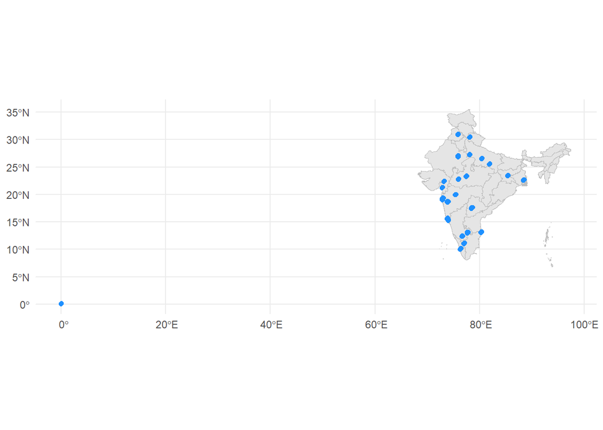

```r
df_map_1 %>%

  ggplot() +
  geom_sf(color = "gray", lwd = 0.1) +
  geom_point(data = df_delivery,
             aes(x = delivery_location_longitude,
                 y = delivery_location_latitude
                 ),

             alpha = 0.5, color = "dodgerblue"
             ) +
  theme_minimal() +

  labs(x = NULL,
       y = NULL
       )
```

Based on the plot, we can see that anomalies only happen at the coordinates around 0 latitude and 0 longitude, let’s check these further.

```r
df_1 <- df_delivery %>%
  filter(delivery_location_longitude < 60) %>%
  select_at(vars(contains("delivery_location")))

cat("Number of anomalies: ", nrow(df_1), "\n\n")
```

```
Number of anomalies:  3640
```

```r
df_1 %>%
  summary()
```

```
 delivery_location_latitude delivery_location_longitude
 Min.   :0.01000            Min.   :0.01000
 1st Qu.:0.03000            1st Qu.:0.03000
 Median :0.06000            Median :0.06000
 Mean   :0.06302            Mean   :0.06302
 3rd Qu.:0.09000            3rd Qu.:0.09000
 Max.   :0.13000            Max.   :0.13000
```

There are around 3600 rows with anomaly location. Perhaps this was a faulty location where the system failed to properly locate the customer location. We can get rid of them for now.

```r
df_clean <- df_delivery %>%
  filter(delivery_location_latitude > 10)
```

Let’s redraw our map.

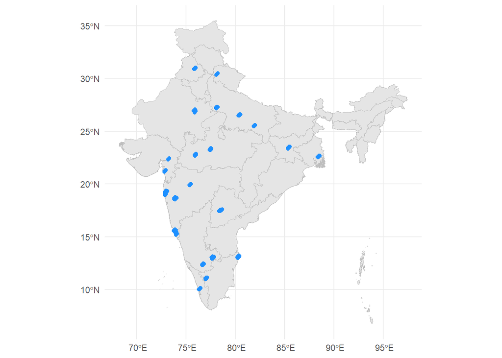

```r
df_map_1 %>%

  ggplot() +
  geom_sf(color = "gray", lwd = 0.1) +
  geom_point(data = df_clean,
             aes(x = delivery_location_longitude,
                 y = delivery_location_latitude
                 ),

             alpha = 0.5, color = "dodgerblue"
             ) +
  theme_minimal() +

  labs(x = NULL,
       y = NULL
       )
```

Here we can see that the customers are concentrated into certain areas. We want to know the name of the area, perhaps in a region or even district level using reverse geocoding.

# Reverse Geocoding

Reverse geocoding can be achieved using 2 methods:

- Online method with API via `tidygeocoder` package
- Offline method with shapefile map data

## Online method with `tidygeocoder`

Online method require us to connect with the API from a geocoding service. The `tidygeocoder` package make it easier for us to connect the API and do the geocoding process. The list of the geocoding service covered by the package can be accessed [here](https://jessecambon.github.io/tidygeocoder/articles/geocoder_services.html).

The online method is a great alternative if you want the correct and proper address based on up to date data. However, it has a drawback to consider. Since we are using API access, we rely on the API usage rate limit and some services require us to create an API key beforehand. The following is the example of using the **Nominatim** service with the Open Street Map data to reverse geocode the first 10 rows of our delivery data.

```r
t_1 <- Sys.time()

df_reverse_tidy <- df_clean %>%
  head(10) %>%
  reverse_geocode(lat = delivery_location_latitude,
                  long = delivery_location_longitude,
                  method = 'osm'
                  )
```

```
Passing 10 coordinates to the Nominatim single coordinate geocoder
```

```
Query completed in: 11 seconds
```

```r
t_2 <- Sys.time()

t_2 - t_1
```

```
Time difference of 10.99025 secs
```

The API will return a column named *address* that give you detailed address for each coordinate.

```r
df_reverse_tidy %>%
  select(id,
         delivery_location_latitude,
         delivery_location_longitude,
         address
         )
```

| id | delivery_location_latitude | delivery_location_longitude | address |
| --- | --- | --- | --- |
| 0x4607 | 22.76505 | 75.91247 | Balaji Heights, Piplya Kumar, Indore, Juni Indore Tahsil, Indore District, Madhya Pradesh, 452001, India |
| 0xb379 | 13.04304 | 77.81324 | Ganagaluru, Hosakote taluk, Bengaluru Rural, Karnataka, 562114, India |
| 0x5d6d | 12.92426 | 77.68840 | Cadence Design Systems (India) Private Limited, 21, RMZ Eco World Rd, RMZ Eco World, Bellanduru, Mahadevapura Zone, Bengaluru, Bangalore East, Bengaluru Urban, Karnataka, 560103, India |
| 0x7a6a | 11.05367 | 77.02649 | Ward 36, East Zone, Coimbatore, Coimbatore North, Coimbatore District, Tamil Nadu, 641001, India |
| 0x70a2 | 13.01279 | 80.28998 | Pattinambakkam, CMWSSB Division 126, Zone 9 Teynampet, Chennai, Chennai District, Tamil Nadu, 600001, India |
| 0x9bb4 | 17.46167 | 78.43832 | Bharath Nagar, Ward 118 Fateh Nagar, Greater Hyderabad Municipal Corporation West Zone, Hyderabad, Balanagar mandal, Medchal–Malkajgiri District, Telangana, 500018, India |
| 0x95b4 | 23.47975 | 85.44982 | MDR016, Ormanjhi, Ranchi District, Jharkhand, 835219, India |
| 0x9eb2 | 12.48206 | 76.73665 | Doddabyadarahalli, Pandavapura taluk, Mandya District, Karnataka, India |
| 0x1102 | 17.56381 | 78.51674 | Shamirpet mandal, Medchal–Malkajgiri District, Telangana, 500100, India |
| 0xcdcd | 30.39797 | 78.11611 | bashwalgaon, rajrajeshwari, Dehradun, Dehradun District, Uttarakhand, 248009, India |

The Nominatim service has the API rate limit of 1 query per second, meaning that each row will take 1 second to process. Since we have more than 40 thousand rows, the process will take forever to finish. Therefore, if you want to use the API, you may need some strategy like using multiple devices or batch processing to speed up the process. You can the discussion related to this topic [here](https://stackoverflow.com/questions/39522306/how-to-do-large-scale-batch-reverse-geo-coding)

## Offline Method Using the Shapefile

### Spatial Join

We can do reverse geocoding using the shapefile data we have downloaded by doing a spatial join process where the system will determine if a location delivery is located inside the border of a certain region. Here we will use layer 2 of the Indian map data.

```r
df_map_2 <- st_read(dsn = "data/gadm41_IND_shp/", layer = "gadm41_IND_2")
```

The process require the following steps:

1. Converting latitude and longitude of each delivery into proper `sf` geometry point
2. Spatial join using the *st_join()* function to determine whether each point to belong inside certain area using the *st_within* method
3. Return the state name and the region name

```r
# return selected column
selected_column <- df_clean %>%
  select_at(vars(!contains("delivery_location"))) %>%
  names()

# reverse geocoding
df_clean <- df_clean %>%

  # convert latitude and longitude into proper sf point geometry
  st_as_sf(coords = c("delivery_location_longitude", "delivery_location_latitude"),
           crs = st_crs(df_map_2)
           ) %>%

  # spatial join to determine the area of each point
  st_join(df_map_2,
          join = st_within
          ) %>%

  as.data.frame() %>%
  select(
         geometry,
         state_name = NAME_1,
         region_name = NAME_2,
         all_of(selected_column),
         geometry
         )

df_clean %>%
  head(10)
```

|  | geometry | state_name | region_name | id | delivery_person_id | delivery_person_age | delivery_person_ratings | restaurant_latitude | restaurant_longitude | order_date | time_orderd | time_order_picked | weatherconditions | road_traffic_density | vehicle_condition | type_of_order | type_of_vehicle | multiple_deliveries | festival | city | time_taken_min |
| --- | --- | --- | --- | --- | --- | --- | --- | --- | --- | --- | --- | --- | --- | --- | --- | --- | --- | --- | --- | --- | --- |
| 1 |  | Madhya Pradesh | Indore | 0x4607 | INDORES13DEL02 | 37 | 4.9 | 22.74505 | 75.89247 | 19-03-2022 | 11:30:00 | 11:45:00 | conditions Sunny | High | 2 | Snack | motorcycle | 0 | No | Urban | (min) 24 |
| 2 |  | Karnataka | Bangalore Rural | 0xb379 | BANGRES18DEL02 | 34 | 4.5 | 12.91304 | 77.68324 | 25-03-2022 | 19:45:00 | 19:50:00 | conditions Stormy | Jam | 2 | Snack | scooter | 1 | No | Metropolitian | (min) 33 |
| 3 |  | Karnataka | Bangalore | 0x5d6d | BANGRES19DEL01 | 23 | 4.4 | 12.91426 | 77.67840 | 19-03-2022 | 08:30:00 | 08:45:00 | conditions Sandstorms | Low | 0 | Drinks | motorcycle | 1 | No | Urban | (min) 26 |
| 4 |  | Tamil Nadu | Coimbatore | 0x7a6a | COIMBRES13DEL02 | 38 | 4.7 | 11.00367 | 76.97649 | 05-04-2022 | 18:00:00 | 18:10:00 | conditions Sunny | Medium | 0 | Buffet | motorcycle | 1 | No | Metropolitian | (min) 21 |
| 5 |  | NA | NA | 0x70a2 | CHENRES12DEL01 | 32 | 4.6 | 12.97279 | 80.24998 | 26-03-2022 | 13:30:00 | 13:45:00 | conditions Cloudy | High | 1 | Snack | scooter | 1 | No | Metropolitian | (min) 30 |
| 6 |  | Telangana | Ranga Reddy | 0x9bb4 | HYDRES09DEL03 | 22 | 4.8 | 17.43167 | 78.40832 | 11-03-2022 | 21:20:00 | 21:30:00 | conditions Cloudy | Jam | 0 | Buffet | motorcycle | 1 | No | Urban | (min) 26 |
| 7 |  | Jharkhand | Ranchi | 0x95b4 | RANCHIRES15DEL01 | 33 | 4.7 | 23.36975 | 85.33982 | 04-03-2022 | 19:15:00 | 19:30:00 | conditions Fog | Jam | 1 | Meal | scooter | 1 | No | Metropolitian | (min) 40 |
| 8 |  | Karnataka | Mandya | 0x9eb2 | MYSRES15DEL02 | 35 | 4.6 | 12.35206 | 76.60665 | 14-03-2022 | 17:25:00 | 17:30:00 | conditions Cloudy | Medium | 2 | Meal | motorcycle | 1 | No | Metropolitian | (min) 32 |
| 9 |  | Telangana | Ranga Reddy | 0x1102 | HYDRES05DEL02 | 22 | 4.8 | 17.43381 | 78.38674 | 20-03-2022 | 20:55:00 | 21:05:00 | conditions Stormy | Jam | 0 | Buffet | motorcycle | 1 | No | Metropolitian | (min) 34 |
| 10 |  | Uttarakhand | Dehradun | 0xcdcd | DEHRES17DEL01 | 36 | 4.2 | 30.32797 | 78.04611 | 12-02-2022 | 21:55:00 | 22:10:00 | conditions Fog | Jam | 2 | Snack | motorcycle | 3 | No | Metropolitian | (min) 46 |

We find that there is a location that has no name of area. Let’s visualize and check where most of these data is located.

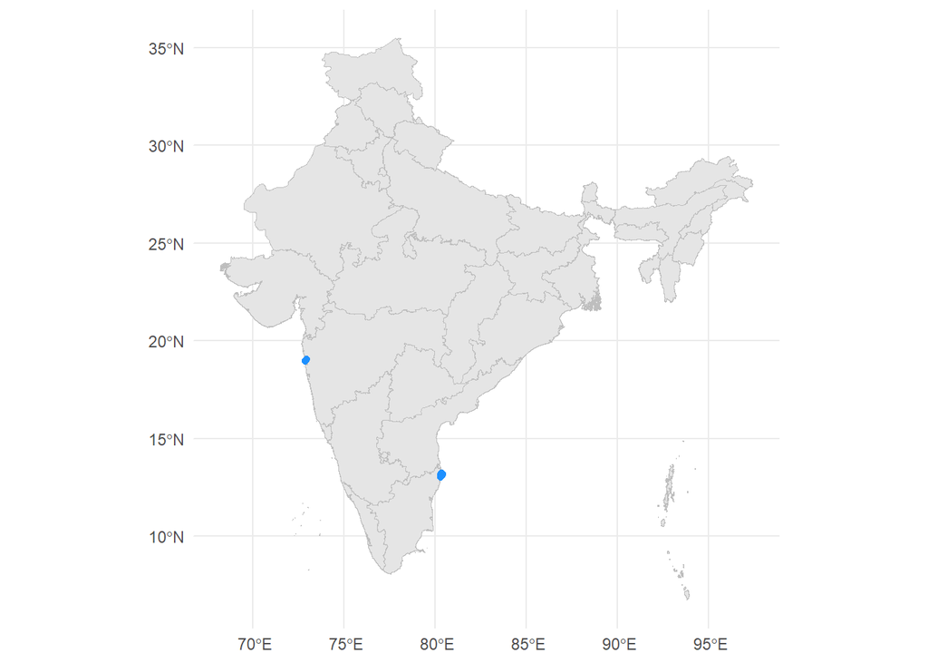

```r
df_2 <- df_clean %>%
  filter(is.na(region_name)) %>%
  st_as_sf()

df_map_1 %>%

  ggplot() +
  geom_sf(color = "gray", lwd = 0.1) +
  geom_sf(data = df_2,

             alpha = 0.5, color = "dodgerblue"
             ) +
  theme_minimal() +

  labs(x = NULL,
       y = NULL
       )
```

There are 2 concentrated area where we failed to reverse geocode and both are located near the sea. We may assume that these locaton is out of the land border and located on the sea, therefore we fail to fetch their area.

Let’s zoom in on the bottom right area.

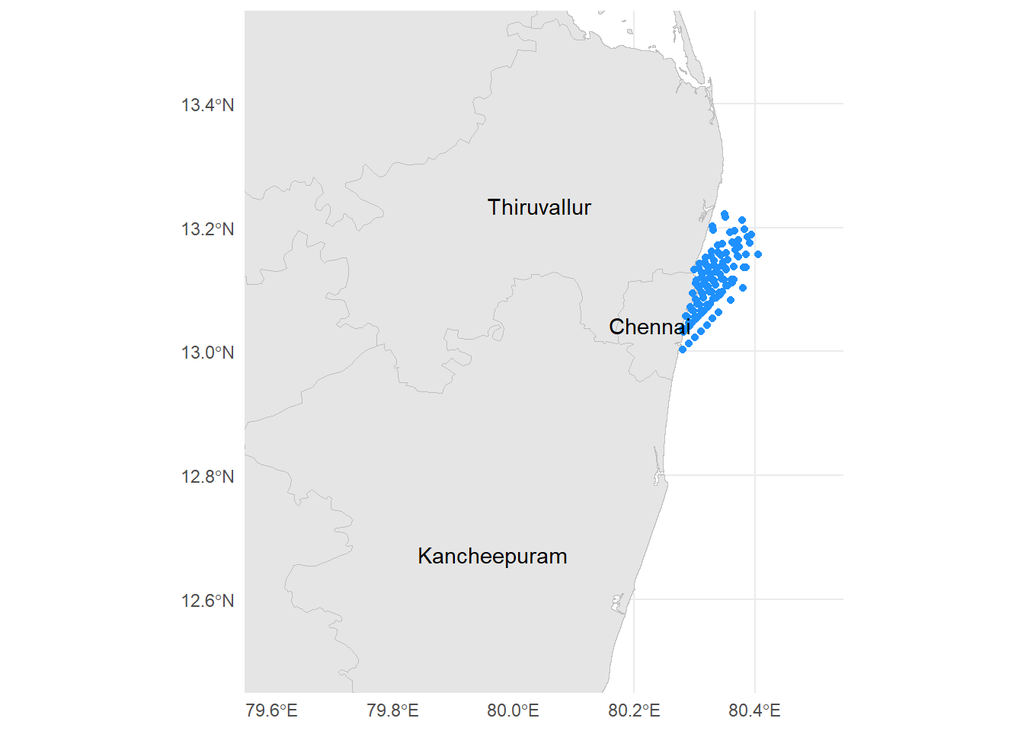

```r
df_map_2 %>%

  ggplot() +
  geom_sf(color = "gray", lwd = 0.1) +
  geom_sf(data = df_2,

             alpha = 0.5, color = "dodgerblue"
             ) +
  geom_sf_text(aes(label = NAME_2)) +
  theme_minimal() +
  coord_sf(xlim = c(79.6, 80.5),
           ylim = c(12.5, 13.5)
           ) +

  labs(x = NULL,
       y = NULL
       )
```

Let’s zoom in on the upper left area as well.

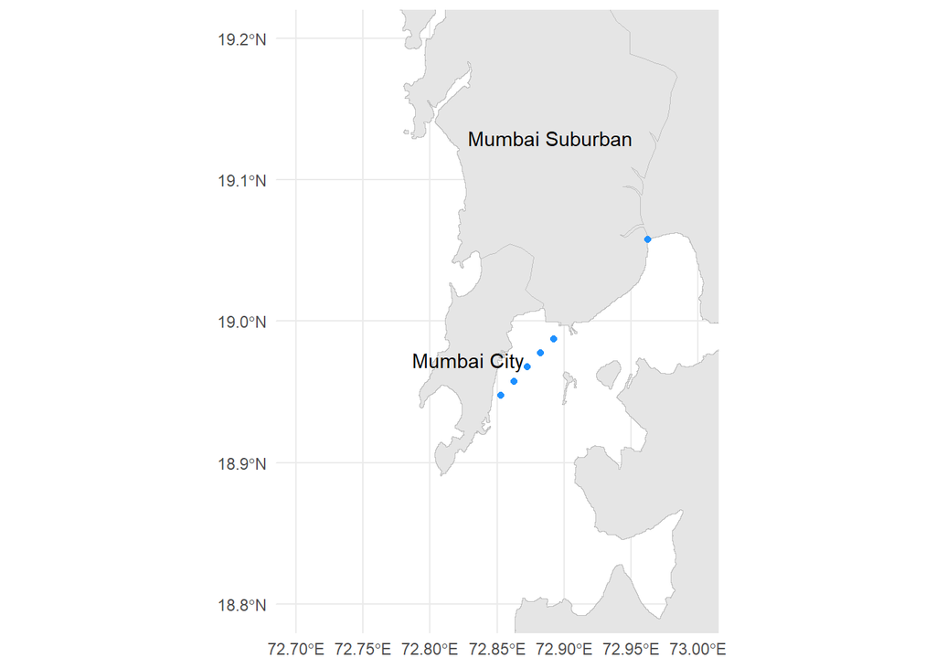

```r
df_map_2 %>%

  ggplot() +
  geom_sf(color = "gray", lwd = 0.1) +
  geom_sf(data = df_2,

             alpha = 0.5, color = "dodgerblue"
             ) +
  geom_sf_text(aes(label = NAME_2)) +
  theme_minimal() +
  coord_sf(xlim = c(72.7, 73),
           ylim = c(18.8, 19.2)
           ) +

  labs(x = NULL,
       y = NULL
       )
```

Yep, it seems that our previous assumption is correct. Since the point is located outside any area, the *st_join()* fail to find the name of the region since we use the *st_within()* function to look inside each border. To mitigate this problem, we may need to determine the closest area by calculating the distance between the point and the polygon.

### Distance to Nearest Border

We will do simple loop to check the closest area for each point. Since we are calculating the distance of multiple points into multiple areas, this process may take a while. To speed up the process of calculating the distance, first we will filter the region border dataset to only cover area that make sense. For example, we don’t need to include the far north region near China or Bangladesh since they are nowhere near the concentrated area. We will get the area where the centroid or the center of the border is located on our defined coordinates.

```r
df_selected_map <- df_map_2 %>%
  filter(
         (st_coordinates(st_centroid(.))[,"X"]  %>% between(72, 74) | st_coordinates(st_centroid(.))[,"X"]  %>% between(79, 81)),
         st_coordinates(st_centroid(.))[,"Y"] %>% between(18.5, 20.5) | st_coordinates(st_centroid(.))[,"Y"] %>% between(12.5, 13.5)
         )
```

[output not shown]

You can ignore the warning message.

```r
cat("Remaining region: ", nrow(df_selected_map))
```

```
Remaining region:  16
```

We have filtered from 600+ regions into under 30 regions. Now we will calculated the closest region for each delivery point. This may not be the optimal or the fastest way to get the distance but I hope it is simple enough for you to understand.

```r
region_name <- df_selected_map$NAME_2
state_name <- df_selected_map$NAME_1

df_closest_area <- map_df(1:nrow(df_2),
                          function(x) {

                            # calculate the distance
                            point_distance <- st_distance(df_2$geometry[x], df_selected_map)

                            # get the closest area
                            close_state <- state_name[ which.min(point_distance) ]
                            close_region <- region_name[ which.min(point_distance) ]

                            # return the result
                            data.frame(id = df_2$id[x],
                                       close_state,
                                       close_region
                                       ) %>%
                              return()
                          }

                          )

df_closest_area %>%
  head()
```

|  | id | close_state | close_region |
| --- | --- | --- | --- |
| 1 | 0x70a2 | Tamil Nadu | Chennai |
| 2 | 0xb816 | Tamil Nadu | Chennai |
| 3 | 0xa1b2 | Tamil Nadu | Chennai |
| 4 | 0x5d99 | Tamil Nadu | Thiruvallur |
| 5 | 0xa258 | Tamil Nadu | Chennai |
| 6 | 0xb962 | Tamil Nadu | Thiruvallur |

Let’s combine this information to our initial reverse geocoding result. We also process the *time_taken_min* column into proper numeric format by extracting only the number from the string text.

```r
df_result <- df_clean %>%
  left_join(df_closest_area,
            by = join_by(id)
            ) %>%
  mutate(state_name = ifelse(is.na(state_name), close_state, state_name),
         region_name = ifelse(is.na(region_name), close_region, region_name),

         time_taken_min = time_taken_min %>%
           str_extract("[0-9].*[0-9]") %>%
           as.numeric()
         )

df_result %>%
  head(10)
```

|  | geometry | state_name | region_name | id | delivery_person_id | delivery_person_age | delivery_person_ratings | restaurant_latitude | restaurant_longitude | order_date | time_orderd | time_order_picked | weatherconditions | road_traffic_density | vehicle_condition | type_of_order | type_of_vehicle | multiple_deliveries | festival | city | time_taken_min | close_state | close_region |
| --- | --- | --- | --- | --- | --- | --- | --- | --- | --- | --- | --- | --- | --- | --- | --- | --- | --- | --- | --- | --- | --- | --- | --- |
| 1 |  | Madhya Pradesh | Indore | 0x4607 | INDORES13DEL02 | 37 | 4.9 | 22.74505 | 75.89247 | 19-03-2022 | 11:30:00 | 11:45:00 | conditions Sunny | High | 2 | Snack | motorcycle | 0 | No | Urban | 24 | NA | NA |
| 2 |  | Karnataka | Bangalore Rural | 0xb379 | BANGRES18DEL02 | 34 | 4.5 | 12.91304 | 77.68324 | 25-03-2022 | 19:45:00 | 19:50:00 | conditions Stormy | Jam | 2 | Snack | scooter | 1 | No | Metropolitian | 33 | NA | NA |
| 3 |  | Karnataka | Bangalore | 0x5d6d | BANGRES19DEL01 | 23 | 4.4 | 12.91426 | 77.67840 | 19-03-2022 | 08:30:00 | 08:45:00 | conditions Sandstorms | Low | 0 | Drinks | motorcycle | 1 | No | Urban | 26 | NA | NA |
| 4 |  | Tamil Nadu | Coimbatore | 0x7a6a | COIMBRES13DEL02 | 38 | 4.7 | 11.00367 | 76.97649 | 05-04-2022 | 18:00:00 | 18:10:00 | conditions Sunny | Medium | 0 | Buffet | motorcycle | 1 | No | Metropolitian | 21 | NA | NA |
| 5 |  | Tamil Nadu | Chennai | 0x70a2 | CHENRES12DEL01 | 32 | 4.6 | 12.97279 | 80.24998 | 26-03-2022 | 13:30:00 | 13:45:00 | conditions Cloudy | High | 1 | Snack | scooter | 1 | No | Metropolitian | 30 | Tamil Nadu | Chennai |
| 6 |  | Telangana | Ranga Reddy | 0x9bb4 | HYDRES09DEL03 | 22 | 4.8 | 17.43167 | 78.40832 | 11-03-2022 | 21:20:00 | 21:30:00 | conditions Cloudy | Jam | 0 | Buffet | motorcycle | 1 | No | Urban | 26 | NA | NA |
| 7 |  | Jharkhand | Ranchi | 0x95b4 | RANCHIRES15DEL01 | 33 | 4.7 | 23.36975 | 85.33982 | 04-03-2022 | 19:15:00 | 19:30:00 | conditions Fog | Jam | 1 | Meal | scooter | 1 | No | Metropolitian | 40 | NA | NA |
| 8 |  | Karnataka | Mandya | 0x9eb2 | MYSRES15DEL02 | 35 | 4.6 | 12.35206 | 76.60665 | 14-03-2022 | 17:25:00 | 17:30:00 | conditions Cloudy | Medium | 2 | Meal | motorcycle | 1 | No | Metropolitian | 32 | NA | NA |
| 9 |  | Telangana | Ranga Reddy | 0x1102 | HYDRES05DEL02 | 22 | 4.8 | 17.43381 | 78.38674 | 20-03-2022 | 20:55:00 | 21:05:00 | conditions Stormy | Jam | 0 | Buffet | motorcycle | 1 | No | Metropolitian | 34 | NA | NA |
| 10 |  | Uttarakhand | Dehradun | 0xcdcd | DEHRES17DEL01 | 36 | 4.2 | 30.32797 | 78.04611 | 12-02-2022 | 21:55:00 | 22:10:00 | conditions Fog | Jam | 2 | Snack | motorcycle | 3 | No | Metropolitian | 46 | NA | NA |

# Data Analysis

Let’s do some simple analysis by looking at the number of delivery order for each region. The following is the top 10 region with most count of delivery.

```r
df_out_1 <- df_result %>%
  group_by(state_name, region_name) %>%
  summarise(count_delivery = n_distinct(id),
            avg_delivery_time = mean(time_taken_min),
            .groups = "drop"
            ) %>%
  arrange(desc(count_delivery))

df_out_1 %>%
  head(10)
```

| state_name | region_name | count_delivery | avg_delivery_time |
| --- | --- | --- | --- |
| Rajasthan | Jaipur | 3443 | 26.69213 |
| Gujarat | Surat | 3187 | 26.08158 |
| Maharashtra | Pune | 3132 | 26.34419 |
| Telangana | Ranga Reddy | 2993 | 26.58804 |
| Karnataka | Bangalore | 2883 | 25.71974 |
| Madhya Pradesh | Indore | 2869 | 25.76020 |
| Jharkhand | Ranchi | 2564 | 26.39353 |
| Tamil Nadu | Coimbatore | 2444 | 25.23159 |
| Tamil Nadu | Chennai | 2252 | 25.21137 |
| Karnataka | Mandya | 1883 | 27.97823 |

What is the distribution of each *type_of_order* on each region?

```r
df_result %>%
  group_by(state_name, region_name, type_of_order) %>%
  summarise(count_delivery = n_distinct(id),
            .groups = "drop"
            ) %>%
  pivot_wider(names_from = type_of_order,
              values_from = count_delivery
              ) %>%
  left_join(df_out_1,
            by = join_by(state_name, region_name)
            ) %>%
  arrange(desc(count_delivery))
```

| state_name | region_name | Buffet | Drinks | Meal | Snack | count_delivery | avg_delivery_time |
| --- | --- | --- | --- | --- | --- | --- | --- |
| Rajasthan | Jaipur | 830 | 882 | 894 | 837 | 3443 | 26.69213 |
| Gujarat | Surat | 772 | 836 | 815 | 764 | 3187 | 26.08158 |
| Maharashtra | Pune | 763 | 798 | 792 | 779 | 3132 | 26.34419 |
| Telangana | Ranga Reddy | 773 | 698 | 750 | 772 | 2993 | 26.58804 |
| Karnataka | Bangalore | 663 | 725 | 749 | 746 | 2883 | 25.71974 |
| Madhya Pradesh | Indore | 715 | 721 | 723 | 710 | 2869 | 25.76020 |
| Jharkhand | Ranchi | 631 | 637 | 653 | 643 | 2564 | 26.39353 |
| Tamil Nadu | Coimbatore | 615 | 628 | 594 | 607 | 2444 | 25.23159 |
| Tamil Nadu | Chennai | 546 | 580 | 551 | 575 | 2252 | 25.21137 |
| Karnataka | Mandya | 473 | 461 | 469 | 480 | 1883 | 27.97823 |

[output cut: 30 more lines]

# Summary

Reverse geocoding is essential if you want to understand the customer behavior on particular region. For example, as a food delivery service or a food merchant offers or partners with a delivery service, you want to know where most of your customers are located based on their delivery addresses. Reverse geocoding can be achieved using 2 methods:

- Online method with API via `tidygeocoder` package
- Offline method with shapefile map data

Both are useful and can give us great result. The drawback of using online method is that we are limited by the API usage rate and generally take longer time to process a lot of data, while the drawback of using the offline method is that we require correct and proper map data and be wary of data located outside the border.